# Résultats Stroop longueur orthographique

Eric Ménétré

23/03/2020

## Introduction

#### Question de recherche

la forme orthographique du mot est-elle activée lors de la dénomination de couleur ? Est-il possible d’inférer un effet d’interférence à ce niveau ?

#### Manipulation

Dénomination de couleur sur base de présentations de rangées de X écrits en différentes couleurs. La manipulation touche la longueur de la rangée de X. Le nombre de X peut soit correspondre au nombre de caractères contenus dans le mot de couleur ou non. Deux conditions s’opposent :

- Même nombre de X que le nom de la couleur contient de caractères -> pas d’interférence (ligne de base)
- Nombre plus petit ou plus grands de X que le nom de la couleur contient de caractères -> condition interférente

#### Stimuli

4 couleurs choisies :

- Or
- Azur
- Turquoise
- Bordeau

#### Procédure

Les participants sont informés qu’ils vont devoir dénommer en quelle couleurs des rangées de X sont écrites, mais qu’étant donné le fait que les couleurs à dénommer sont peu fréquentes, ils devront effectuer deux étapes d’entrainement.

Dans un premier temps, les rangées de X en différentes couleurs ainsi qu’un enregistrement d’une personne dénommant cette couleur leur est proposé trois fois par couleur. Les rangées de X sont toujours congruentes.

Dans un second temps, les rangées de X leur sont présenté et leur tâche est d’indiquer à l’aide du clavier (touches de 1 à 4) de quelle couleur est la rangée de X présentée. Tous les participants (en tout cas jusque là ont obtenu un taux de réussite supérieur à 80%).

Enfin, les sujets dénomment oralement 92 items de chaque condition. La randomisation a été effectuée par Mix et un algorithme de machine learning (KNN) a montré que les données étaient difficilement prédictibles.

# Résultats

#### Statstiques descriptives

Les données ont été nettoyées au préalable (2.5 SD au dessus et en dessous de la moyenne)

```
##   condition  mean_RT    SD_RT accuracy_res SD_acc_res accuracy_large_res
## 1      cong 684.7076 137.9351    0.9707358  0.1686167          0.9749164
## 2    incong 698.7126 144.2419    0.9665552  0.1798703          0.9732441
##   SD_acc_large
## 1           NA
## 2           NA
```

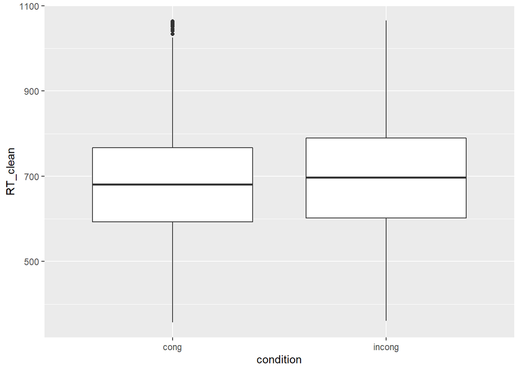

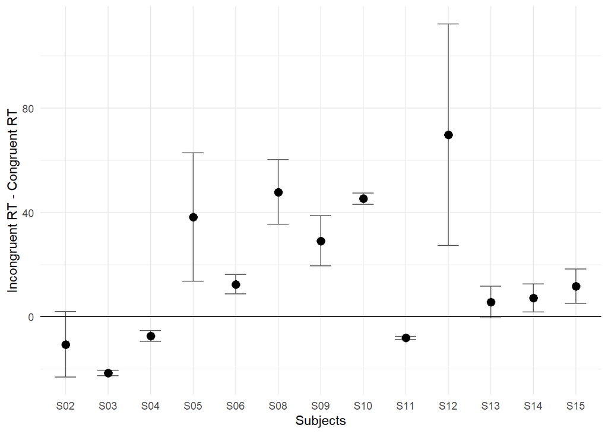

Il y a donc une différence de 14.0050134ms.

Qu’en est-il de l’effet par couleur ?

```r
data_ortholo%>%
  rename(color = repcor)%>%
  group_by(color, condition)%>%
  summarize(MEAN = mean(RT_clean, na.rm = T))%>%
  spread(condition, MEAN)%>%
  mutate(interference = incong-cong)%>%
  rename(congruent = cong,
         incongruent = incong)
```

```
## # A tibble: 4 x 4
## # Groups:   color [4]
##   color     congruent incongruent interference
##   <chr>         <dbl>       <dbl>        <dbl>
## 1 azur           724.        752.        28.2
## 2 bordeau        673.        684.        11.1
## 3 or             659.        672.        13.5
## 4 turquoise      685.        690.         4.26
```

Y a-t-il un effet d’apprentissage au cours de la tâche ?

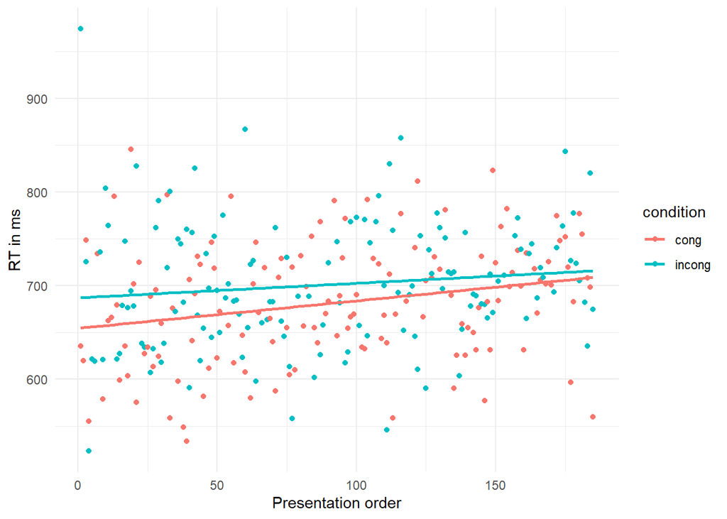

```r
data_ortholo%>%
  group_by(order, condition)%>%
  summarize(RT_mean = mean(RT_clean, na.rm = T),
            RT_SD = sd(RT_clean, na.rm = T))%>%
  ggplot(aes(x = order, y = RT_mean, color = condition)) + geom_point()+
  geom_smooth(method = "lm", se = F) + theme_minimal()+
  labs(x = "Presentation order",
       y = "RT in ms")
```

Afin de vérifier que nous n’ayons pas un effet de priming dû au fait que durant l’entrainement les items sont tous présentés de manière congruente, si un effet de priming a bien eu lieu, au cours des essais, il devrait diminuer. On devrait donc retrouver un effet d’interférence minimal au début de la tâche puis le voir augmenter à nouveau vers la fin. Ici nous observond l’inverse, indiquant plus un effet de fatigue qu’un effet de priming. Fait intéressant, l’effet de fatigue semble plus toucher la condition congruente qu’incongruente, pouvant être interprété comme une charge attentionnelle nécessaire pour l’incongruence supérieureà celle nécessaire pour traiter un item congruent.

#### Modèles mixtes

Evaluation des postulats du modèle:

```r
m0 <- lmer(RT_clean ~ 1 + (1|subject) + (1|repcor), data = data_ortholo, REML = T)
summary(m0)
```

```
## Linear mixed model fit by REML. t-tests use Satterthwaite's method [
## lmerModLmerTest]
## Formula: RT_clean ~ 1 + (1 | subject) + (1 | repcor)
##    Data: data_ortholo
##
## REML criterion at convergence: 27519.3
##
## Scaled residuals:
##     Min      1Q  Median      3Q     Max
## -2.8618 -0.6172 -0.0290  0.5995  3.3518
##
## Random effects:
##  Groups   Name        Variance Std.Dev.
##  subject  (Intercept)  3189.0   56.47
##  repcor   (Intercept)   982.8   31.35
##  Residual             16323.4  127.76
## Number of obs: 2191, groups:  subject, 13; repcor, 4
##
## Fixed effects:
##             Estimate Std. Error      df t value Pr(>|t|)
## (Intercept)  693.140     22.327   9.302   31.05 1.04e-10 ***
## ---
## Signif. codes:  0 '***' 0.001 '**' 0.01 '*' 0.05 '.' 0.1 ' ' 1
```

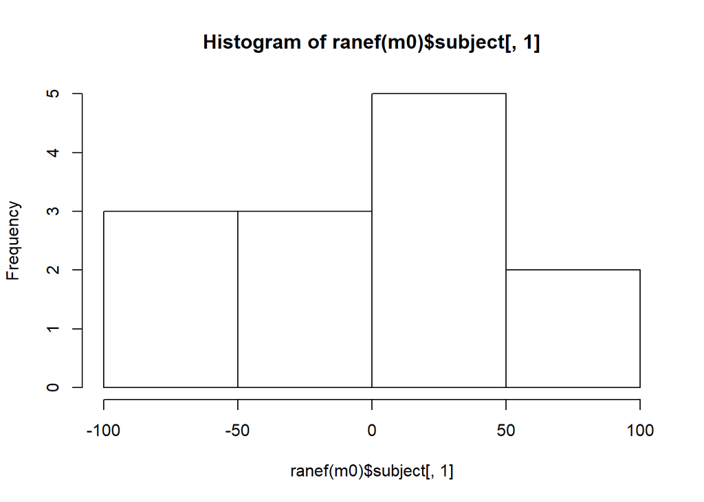

```r
hist(ranef(m0)$subject[,1])
```

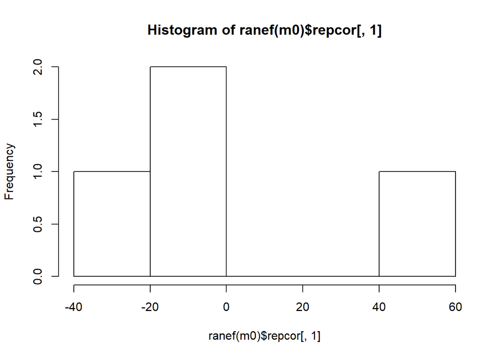

```r
hist(ranef(m0)$repcor[,1])
```

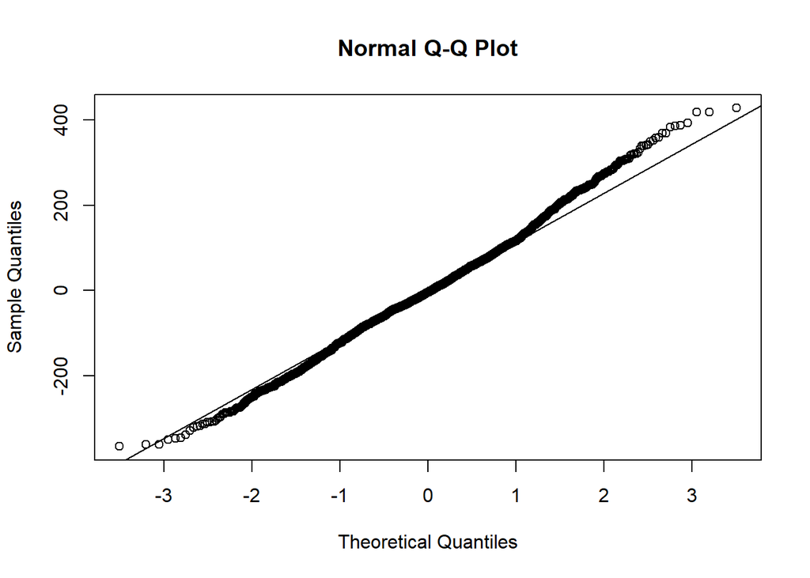

```r
res0 <- residuals(m0)
qqnorm(res0) ; qqline(res0)
```

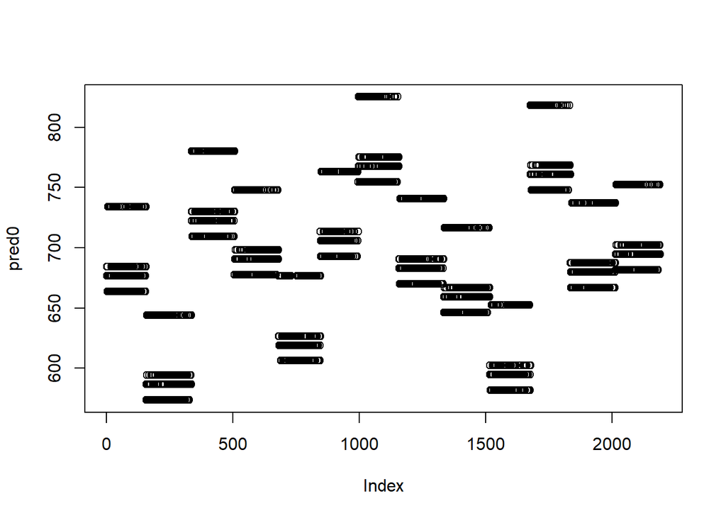

```r
pred0 <- fitted(m0)
plot(pred0)
```

```r
rand(m0)
```

```
## ANOVA-like table for random-effects: Single term deletions
##
## Model:
## RT_clean ~ (1 | subject) + (1 | repcor)
##               npar logLik   AIC    LRT Df Pr(>Chisq)
## <none>           4 -13760 27527
## (1 | subject)    3 -13918 27842 316.37  1  < 2.2e-16 ***
## (1 | repcor)     3 -13802 27610  84.86  1  < 2.2e-16 ***
## ---
## Signif. codes:  0 '***' 0.001 '**' 0.01 '*' 0.05 '.' 0.1 ' ' 1
```

```r
ICC_subj <- round((3189 / (3189 + 982.8 + 16323.4))*100,2)
ICC_item <- round((982.8 / (3189 + 982.8 + 16323.4))*100,2)
```

Les postulats sont respectés. La VD est normalement distribuée, les résidus du modèle sont normalement distribués, la distribution autour de chaque intercept aléatoire est normale également et les deux effets aléatoire améliorent significativement l’explication de la variance résiduelle. En effet, en placant sujet comme variable aléatoire, 15.56% de la variance des données est expliquée alors que seuls 4.8% de la variance totale sont expliqués par les différentes couleurs.

Le modèle complet ne convergeait pas. C’est pourquoi l’optimisateur a été changé pour “nlminb”

```r
data_ortholo$subject <- factor(data_ortholo$subject)
data_ortholo$condition <- factor(data_ortholo$condition)
data_ortholo$condition <- as.numeric(data_ortholo$condition)
data_ortholo$repcor <- factor(data_ortholo$repcor)
data_ortholo$repcor <- as.numeric(data_ortholo$repcor)


m1 <- lmer(RT_clean ~ 1 + (1|subject), data = data_ortholo, REML = F)
anova(m0,m1)
```

```
## refitting model(s) with ML (instead of REML)
```

```
## Data: data_ortholo
## Models:
## m1: RT_clean ~ 1 + (1 | subject)
## m0: RT_clean ~ 1 + (1 | subject) + (1 | repcor)
##    Df   AIC   BIC logLik deviance  Chisq Chi Df Pr(>Chisq)
## m1  3 27617 27635 -13806    27611
## m0  4 27535 27558 -13764    27527 84.188      1  < 2.2e-16 ***
## ---
## Signif. codes:  0 '***' 0.001 '**' 0.01 '*' 0.05 '.' 0.1 ' ' 1
```

```r
m2 <- lmer(RT_clean ~ 1 + (1|subject) + (1|repcor), data = data_ortholo, REML = F)
anova(m1, m2)
```

```
## Data: data_ortholo
## Models:
## m1: RT_clean ~ 1 + (1 | subject)
## m2: RT_clean ~ 1 + (1 | subject) + (1 | repcor)
##    Df   AIC   BIC logLik deviance  Chisq Chi Df Pr(>Chisq)
## m1  3 27617 27635 -13806    27611
## m2  4 27535 27558 -13764    27527 84.188      1  < 2.2e-16 ***
## ---
## Signif. codes:  0 '***' 0.001 '**' 0.01 '*' 0.05 '.' 0.1 ' ' 1
```

```r
m3 <-lmer(RT_clean ~ condition + (1|subject) + (1|repcor), data = data_ortholo, REML = T, control = lmerControl(optimizer = "optimx", calc.derivs = FALSE,
                                                                                                                 optCtrl = list(method = "nlminb", starttests = FALSE, kkt = FALSE)))
anova(m2,m3)
```

```
## refitting model(s) with ML (instead of REML)
```

```
## Data: data_ortholo
## Models:
## m2: RT_clean ~ 1 + (1 | subject) + (1 | repcor)
## m3: RT_clean ~ condition + (1 | subject) + (1 | repcor)
##    Df   AIC   BIC logLik deviance  Chisq Chi Df Pr(>Chisq)
## m2  4 27535 27558 -13764    27527
## m3  5 27528 27557 -13759    27518 8.9891      1   0.002716 **
## ---
## Signif. codes:  0 '***' 0.001 '**' 0.01 '*' 0.05 '.' 0.1 ' ' 1
```

```r
summary(m1)
```

```
## Linear mixed model fit by maximum likelihood . t-tests use Satterthwaite's
##   method [lmerModLmerTest]
## Formula: RT_clean ~ 1 + (1 | subject)
##    Data: data_ortholo
##
##      AIC      BIC   logLik deviance df.resid
##  27617.4  27634.5 -13805.7  27611.4     2188
##
## Scaled residuals:
##     Min      1Q  Median      3Q     Max
## -2.8842 -0.6554 -0.0236  0.6121  3.3632
##
## Random effects:
##  Groups   Name        Variance Std.Dev.
##  subject  (Intercept)  2920     54.04
##  Residual             17055    130.59
## Number of obs: 2191, groups:  subject, 13
##
## Fixed effects:
##             Estimate Std. Error     df t value Pr(>|t|)
## (Intercept)   692.49      15.25  12.99   45.42 1.06e-15 ***
## ---
## Signif. codes:  0 '***' 0.001 '**' 0.01 '*' 0.05 '.' 0.1 ' ' 1
```

Les résultats montrent un effet significatif de conditions (disparaissant avec l’ajout de condition comme pente aléatoire, probablement par manque de sujets).

#### Analyses de puissances

Afin d’obtenir la bonne puissance (éviter d’avoir une étude overpowered ou underpowered), utilisation du package simr pour définir les bons paramètres.

```
## Power for predictor 'condition', (95% confidence interval):
##       80.00% (66.28, 89.97)
##
## Test: unknown test
##       Effect size for condition is 16.
##
## Based on 50 simulations, (0 warnings, 0 errors)
## alpha = 0.05, nrow = 2392
##
## Time elapsed: 0 h 9 m 10 s
##
## nb: result might be an observed power calculation
```

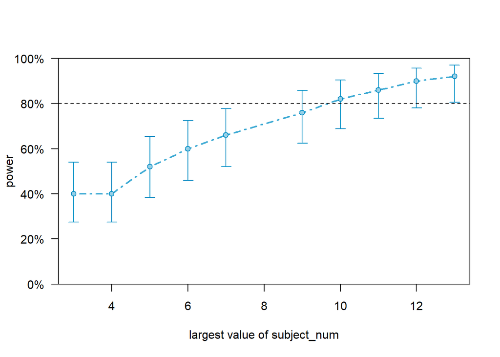

Les résultats de la simulation montrent que 10 sujets sont nécessaires pour atteindre une puissance de 80%. Aussi, avec ce modèle la puissance observée est de 80%. Pour cette étude, il ne faut donc pas dépasser 15 sujets.

# Conclusion

Il seblerait qu’un effet d’interférence existe lié au décodage de la forme orthographique même quand celle-ci n’est pas requise. Ces résultats (s’ils se confirment avec davantage de données), mènent à deux conclusions principales.

1. Si un effet d’interférence est retrouvé, cela suppose qu’un mécanisme lié au décodage orthographique (lequel?) est sous contrôle attentionnel
2. Si un effet d’interférence est présent, ceci remet en cause les modèles strictement sériels tels que le modèle de Levelt et favorise les modèles interactionnistes. Jusque-là (à vérifier) les travaux sur les interactions entre les niveaux théorique du modèle de production ainsi que le modèle de compréhension se sont penchées sur d’éventuelles contamination des autres modules de la production ou de la compréhension mais les interactions entre production et compréhension ne sont que rarement prises en compte, hors des tâches largement utilisées telles que la dénomination d’image ou le PWI devraient selon toute vraisemblance activer le système de compréhension également.